# The options of *fclust_plot*

Benoît Jaillard

2020-11-30

The function *fclust_plot* can conveniently plot the primary and secondary trees of component clustering, observed, modelled and predicted performances of assemblages, composition and mean performances of assembly motifs, mean performances of assemblages containing a given components, or performances of some given assemblages.

## The option *opt.tree*

**opt.tree** manages the plot of primary and secondary trees of component clustering. The option appears as a list of sub-options : *opt.tree = list(“cal”, “prd”, “leg”, cols, “zoom”, window, “all”)*.

- **“cal”** plots the primary tree of component clustering. A blue dashed line indicates the optimum number of component clusters. A red dashed line indicates the value of tree efficiency.
- **“prd”** plots the validated, secondary tree of component clustering. A red dashed line indicates the value of tree efficiency.
- **“leg”** : if **“cal”** or **“prd”** are checked, the option **leg** plots the content in components of validated clusters of the secondary tree.
- **cols** gives *a priori* defined colours to each component. This option is useful to identify some given components, or components *a priori* clustered, into an *a posteriori* clustering.
- **“zoom”** : if **“cal”** or **“prd”** are checked, the option **“zoom”** allows to only plot the first, significant component clusters. **window = n** (n = number of components to plot) must then be informed.
- **“all”** is equivalent to *opt.tree = list(“cal”, “prd”, “leg”)*.

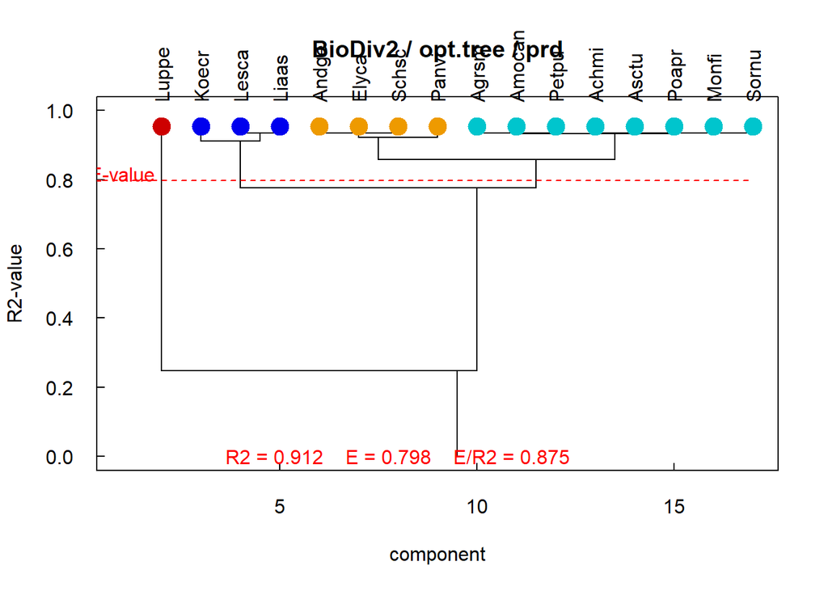

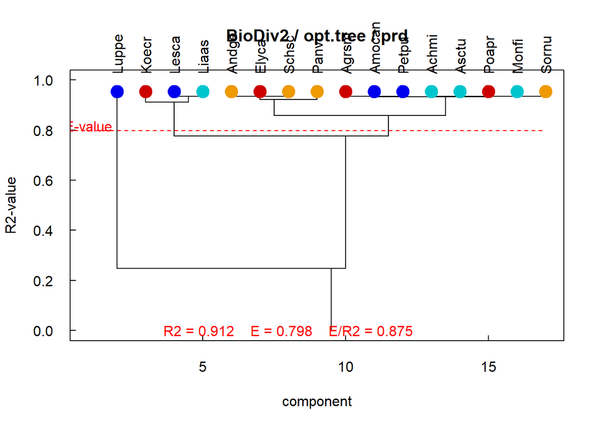

Opt.tree manages the plot of primary and secondary trees

```r
apriori <- c("F","C3","L","C4","F","C3","C3","L","F","L","F","C4","L","C3","C4","C4")
res <- fclust(dat.2004, nbElt, opt.mod = "byelt", opt.mean = "gmean")

fclust_plot(res, main = "BioDiv2", opt.tree = list("prd"))
fclust_plot(res, main = "BioDiv2", opt.tree = list("prd", cols = apriori))
```

## The option *opt.perf*

**opt.perf** manages the plot of observed, modelled and predicted performances of assemblages, and associated statistics. The option appears as a list of sub-options : *opt.perf = list(“stats_I”, “stats_II”, “cal”, “prd”, “pub”, “missing”, “calprd”, “seq”, “ass”, “aov”, pvalue, “all”)*.

- **“stats_I”**, **“stats_II”** plot the statistics associated to fit of primary and secondary trees.

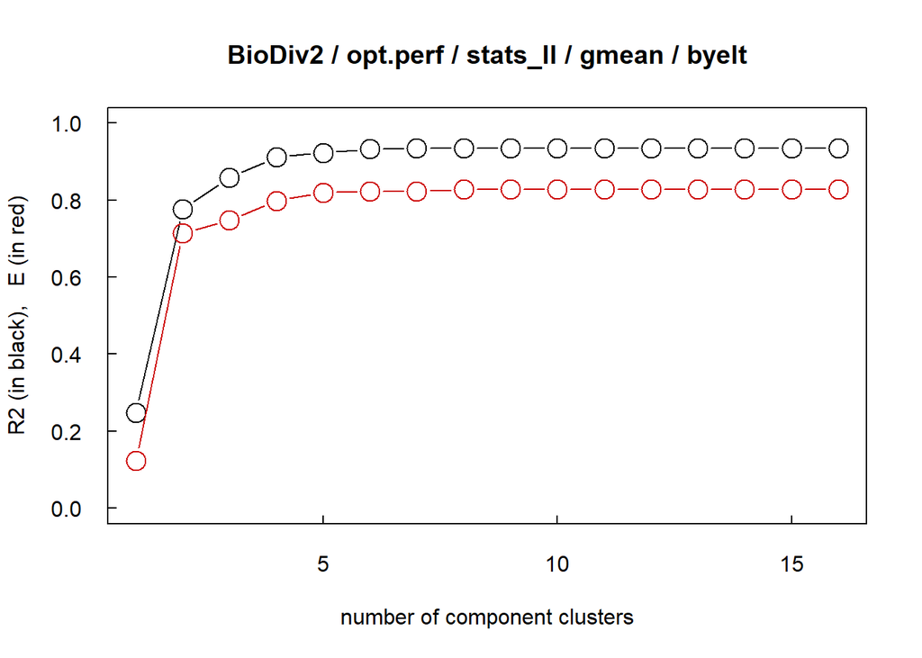

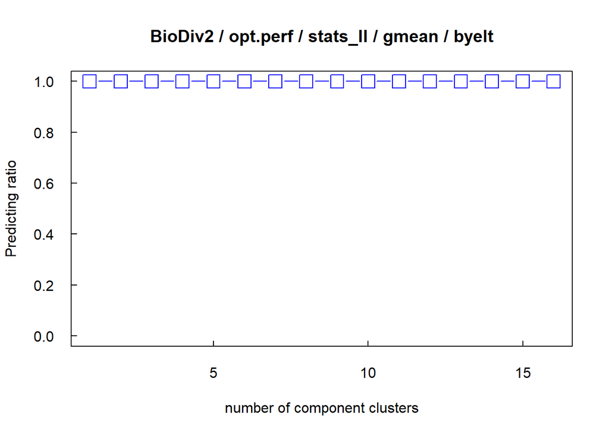

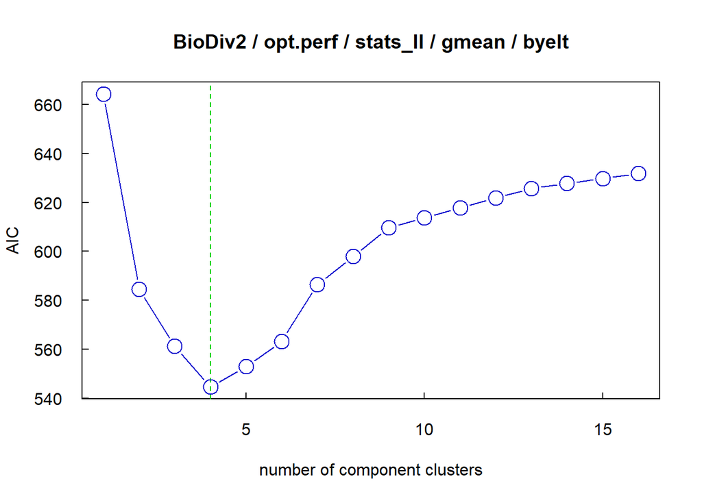

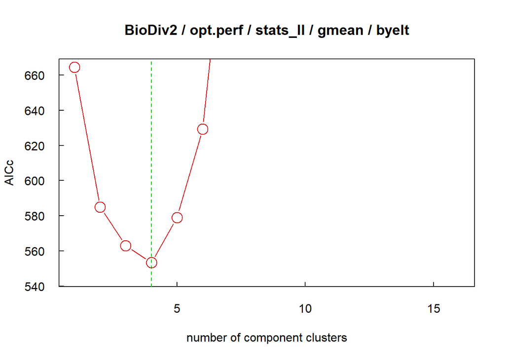

Opt.perf=list(‘stats_xx’) manages the plot of statistics

```r
fclust_plot(res, main = "BioDiv2", opt.perf = list("stats_II"))
```

- **“cal”**, **“prd”**, **“pub”** : **“cal”** plots modelled performance *versus* observed performance, **“prd”** plots performances modelled and predicted by cross-validation *versus* observed performance, **“pub”** plots performances modelled and predicted by cross-validation *versus* observed performance using only one colour and symbol, which is useful for publication.

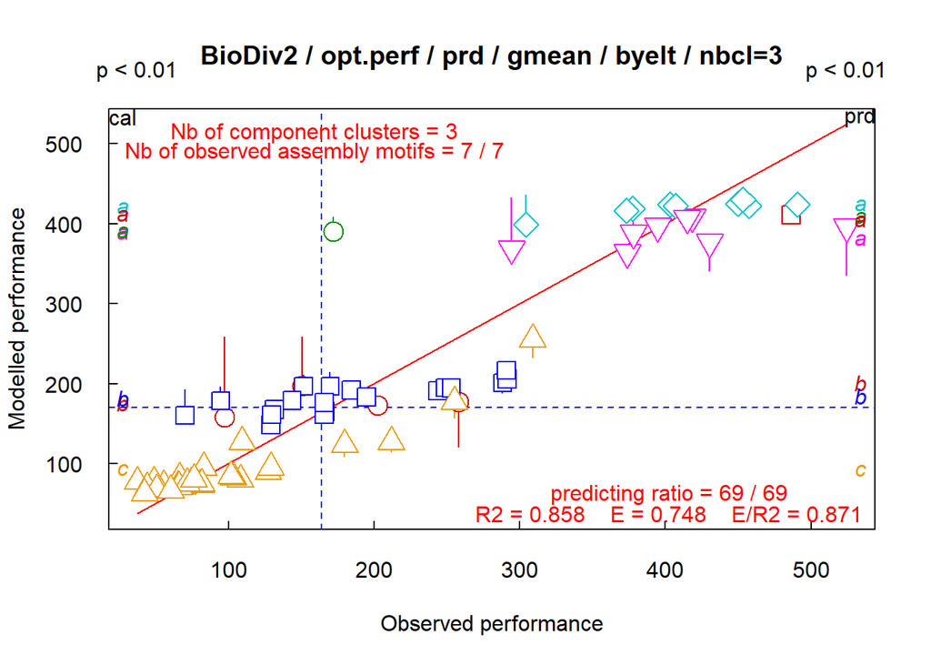

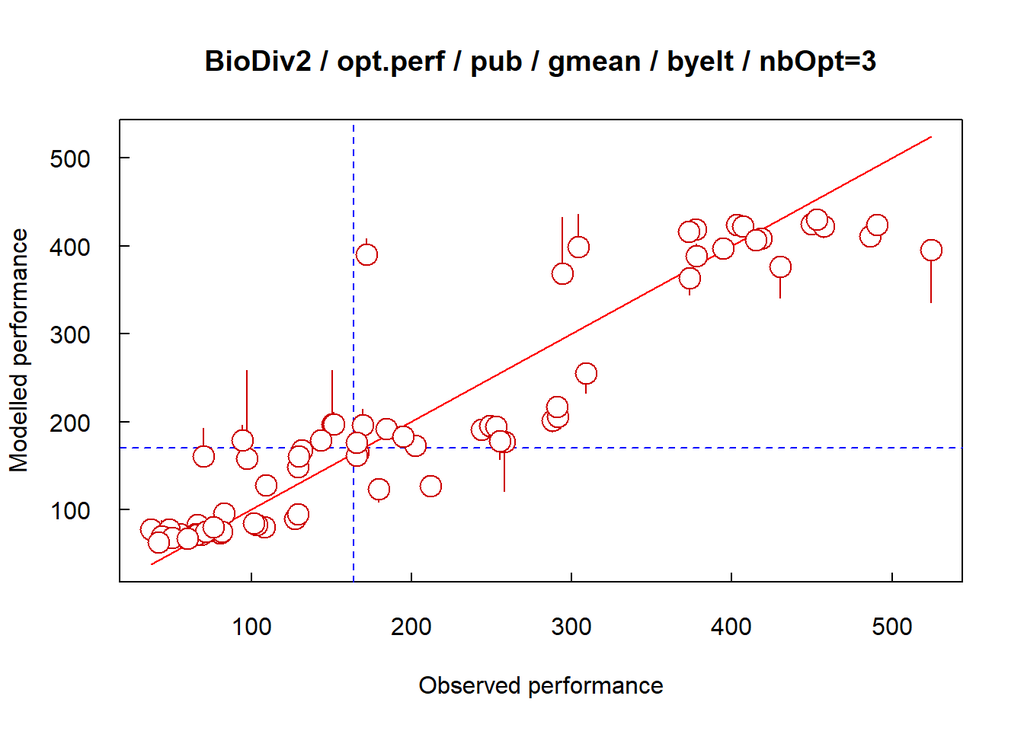

Opt.perf=list(‘prd’) on left, =list(‘pub’) on right

```r
fclust_plot(res, main = "BioDiv2", nbcl = 3, opt.perf = list("prd", "aov", pvalue = 0.01, "pub"))
```

Both graphs show the model goodness-of-fit, left and right graphs differing only by the used colours and symbols. On left graph, the performances of assemblages belonging to different assembly motifs are plotted with different colours and symbols. The symbols correspond to performances predicted by the model (modelled performances), of which the goodness-of-fit is evaluated by tree coefficient of determination *R2*. The vertical lines correspond to performances independently predicted by cross-validation (independently predicted performances), of which the quality is evaluated by tree efficiency *E*. Global statistic are indicated (number of component clusters, number of assembly motifs, *R2*, *E* and the ratio *E/R2*). A variance analysis is indicated on detailled graph, on the left side for modelled performances, on the right side for performances predicted by cross-validation, using a *pvalue = 0.01*. On both graphs, the solid red line is line 1:1, and the blue dashed lines are mean observed and modelled performances.

- **“missing”** identifies the assemblages of which the performance cannot be predicted using the clustering model of the current level.
- **“calprd”** plots performances predicted by cross-validation *versus* performances predicted by clustering model (“modelled performances”).

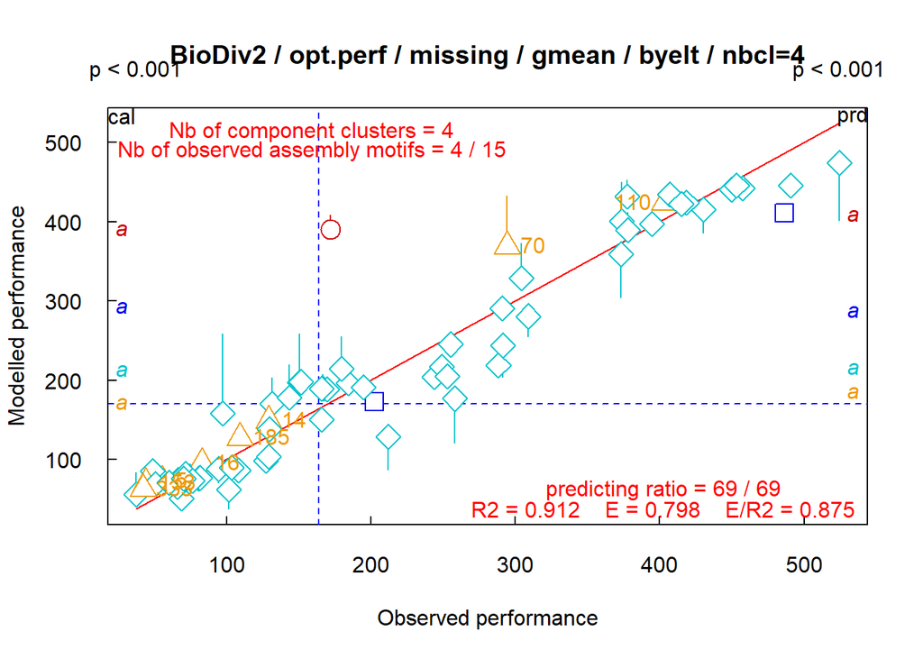

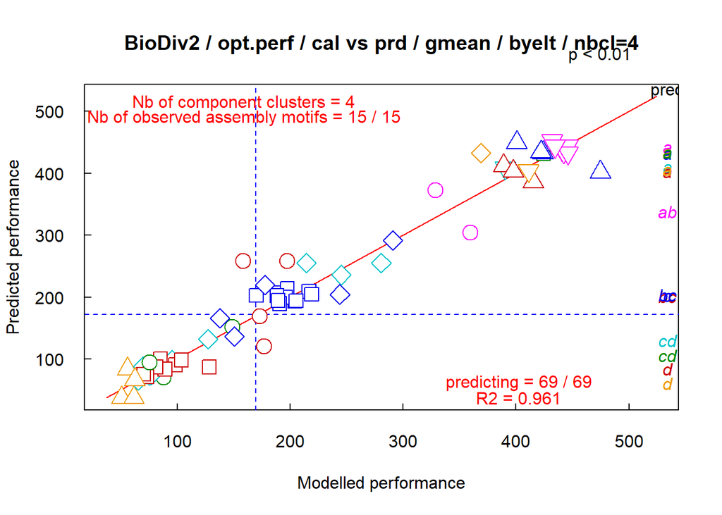

Opt.perf=list(‘missing’) on left, =list(‘calprd’) on right

```r
fclust_plot(res, main = "BioDiv2", nbcl = 4, opt.perf = list("missing"))
fclust_plot(res, main = "BioDiv2", nbcl = 4, opt.perf = list("calprd", "aov", pvalue = 0.01))
```

The right graph shows predicted performances *versus* modelled performances.

- **“seq”** plots performances of assembly motifs, from 1 to the optimum number of component clusters.

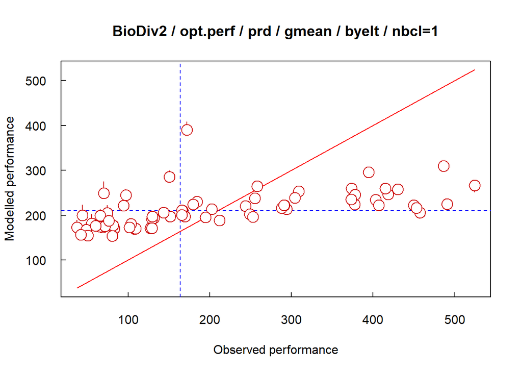

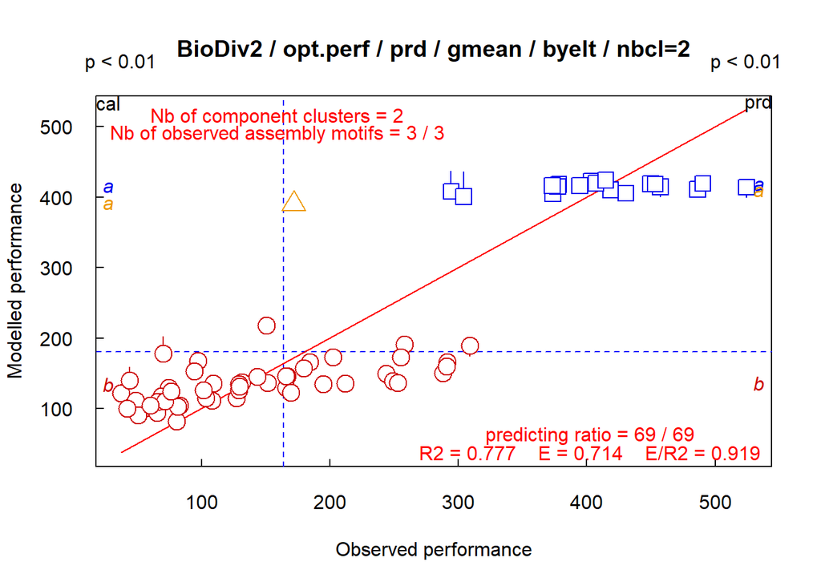

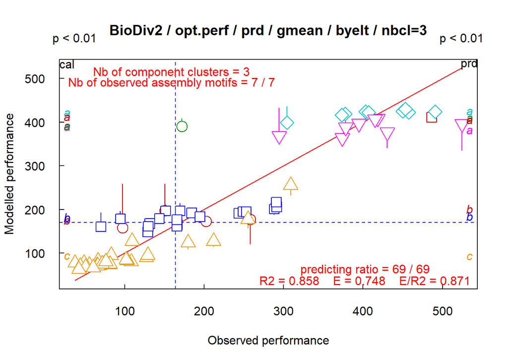

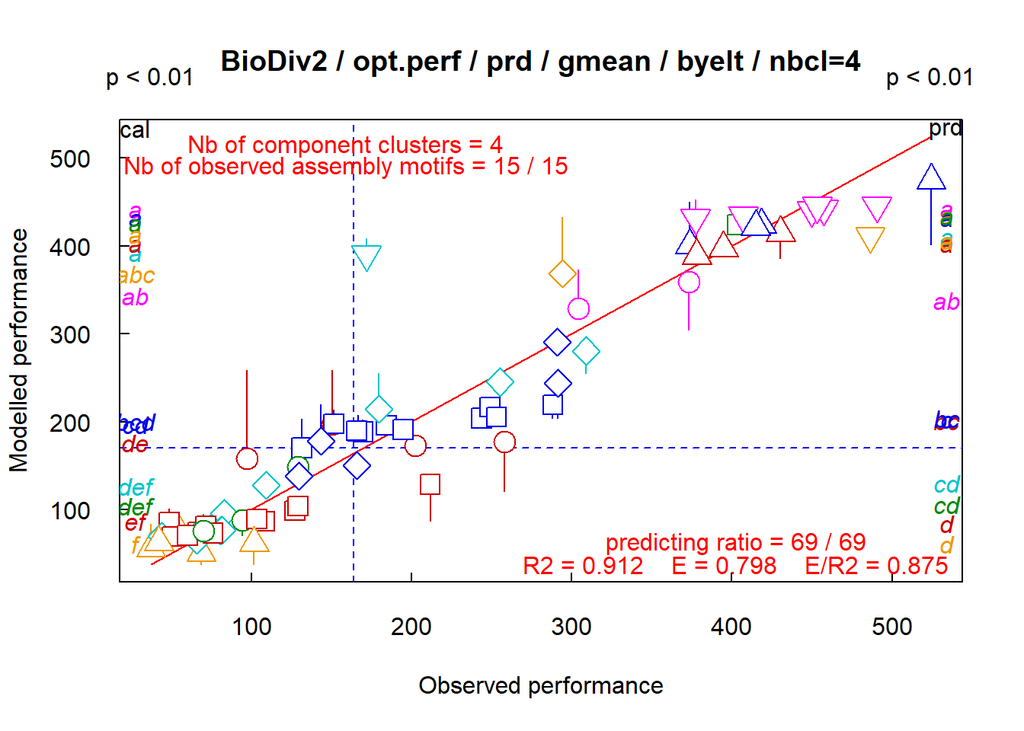

Opt.perf=list(‘prd’, ‘seq’) plots performances predicted from1 to nbOpt component clusters

```r
fclust_plot(res, main = "BioDiv2", opt.perf = list("prd", "seq", "aov", pvalue = 0.01))
```

- **“ass”** plots the name of each assemblage close to its performance.

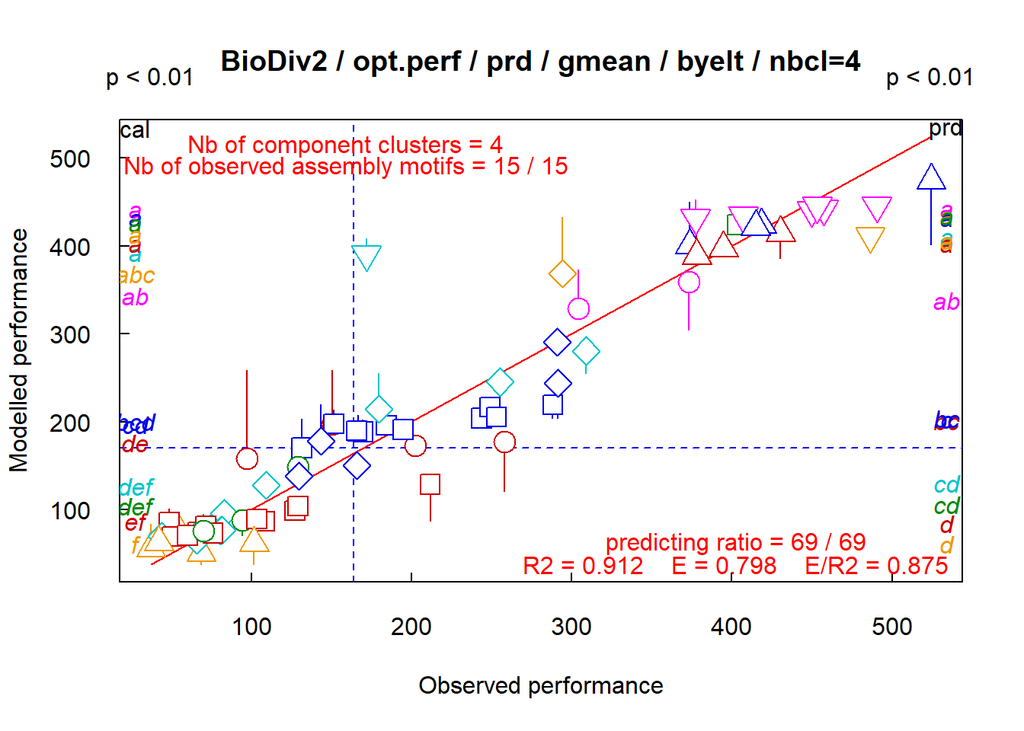

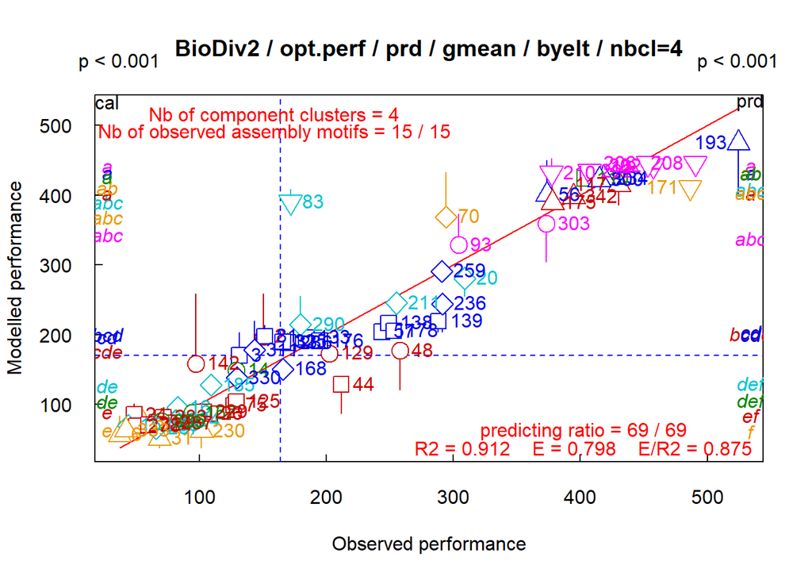

Opt.perf=list(‘prd’, ‘ass’) adds the names of assemblages on plot

```r
fclust_plot(res, main = "BioDiv2", opt.perf = list("prd", "aov", pvalue = 0.01))
fclust_plot(res, main = "BioDiv2", opt.perf = list("prd", "ass"))
```

- **“aov”** does a variance analysis of assemblage performances by assembly motifs, and plot the results. **pvalue = val** (val = threshold of probability) must then be informed. If not, *pvalue = 0.05* by default.
- **“all”** is equivalent to *opt.perf = list(“cal”, “prd”, “pub”, “calprd”, “aov”, pvalue = 0.05)*.

## The option *opt.ass*

**opt.ass** plot different performances of some given, identified assemblages. The option is activated only when an assemblage performance is observed over several experiments (see vignette **The option *xpr* : multi-functionality in *functClust*** ).

## The option *opt.motif*

**opt.motif** manages the plot of mean performances of assembly motifs as boxplots. The option is a list, that can include *opt.motif = list(“obs”, “cal”, “prd”, cols, “hor”, “seq”, pvalue, “all”)*:

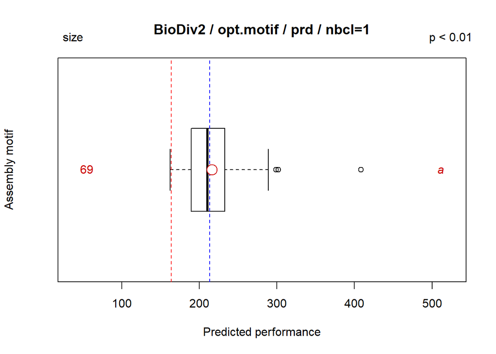

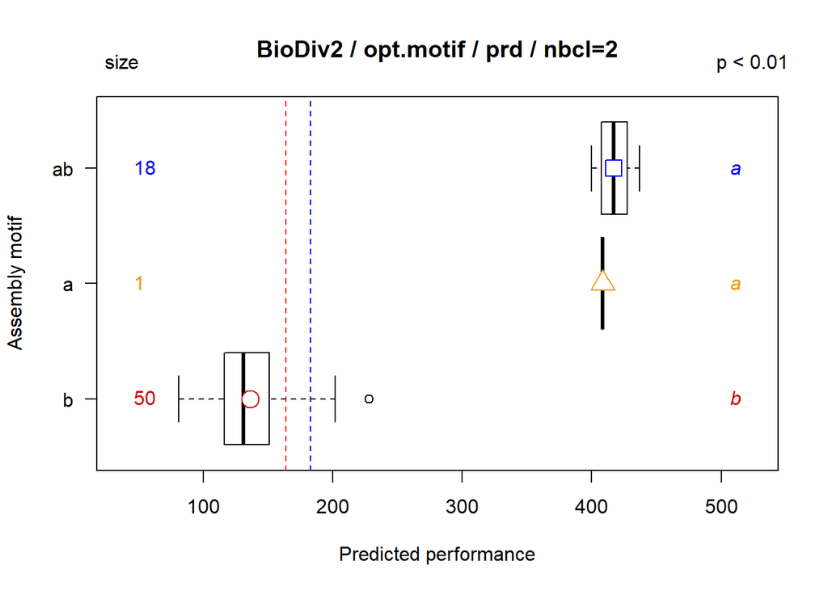

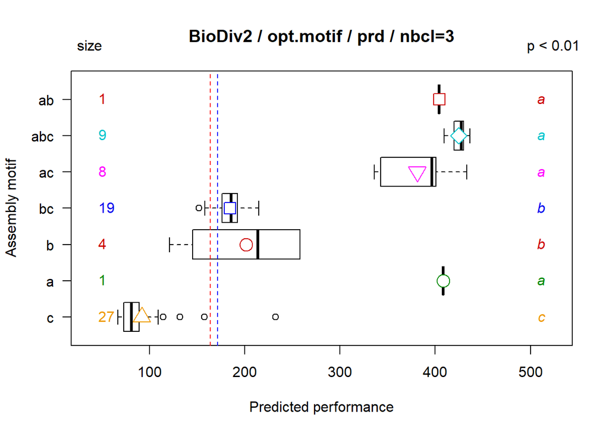

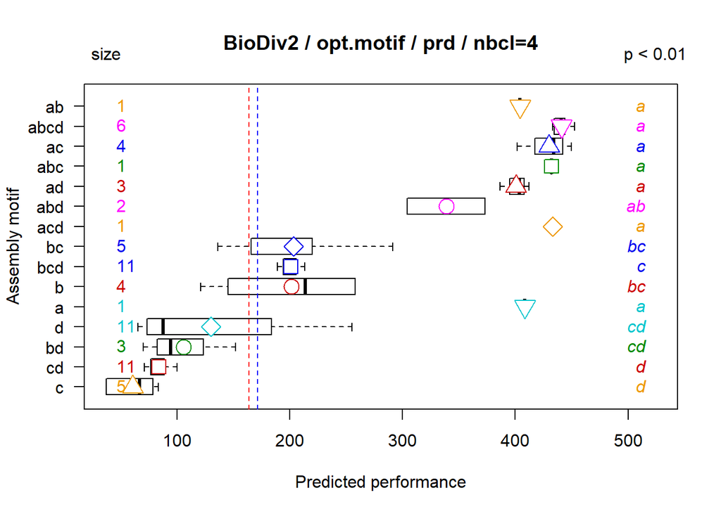

```r
fclust_plot(res, main = "BioDiv2", opt.motif = list("prd", "hor", "seq", "aov", pvalue = 0.01))
```

## The option *opt.comp*

**opt.comp** manages the plot as boxplot of observed mean performances of assemblages that contain a given component. The option can include *opt.comp = list(“tree”, “perf”, “hor”, cols, pvalue, “zoom”, window, “all”)*:

- **“tree”, “perf”** plot the observed mean performances of assemblages that contain a given component as boxplots, sorted like the *clustering tree* or sorted by *increasing mean performance*.
- **“hor”** plot boxplots as horizontal boxes, that is x-axis corresponds to assemblage performances, and y-axis corresponds to assembly motifs.
- **cols** allows to identify specified components, for instance *a priori* clustering into an *a posteriori* clustering.
- **“aov”** does a comparison od means between performance of set of assemblages that contain a given component against performance of set of other assemblages that do not contain the given component in consideration. Each compoent is analised separately. The result is *“a”* if performance of assemblage set is significantly higher, *“b”* if performance of assemblage set is not different, and *“c”* if performance of assemblage set is significantly lower, than performance of set of other assemblages that do not contain the given component. **pvalue = val**(val = threshold of probability) must then be informed. If not, *pvalue = 0.05* by default.
- **“all”** is equivalent to *opt.comp = list(“tree”, “aov”, pvalue = 0.05, “zoom”, window = 20)*.

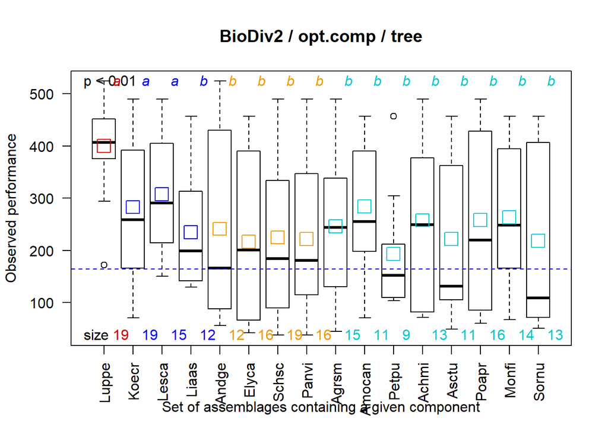

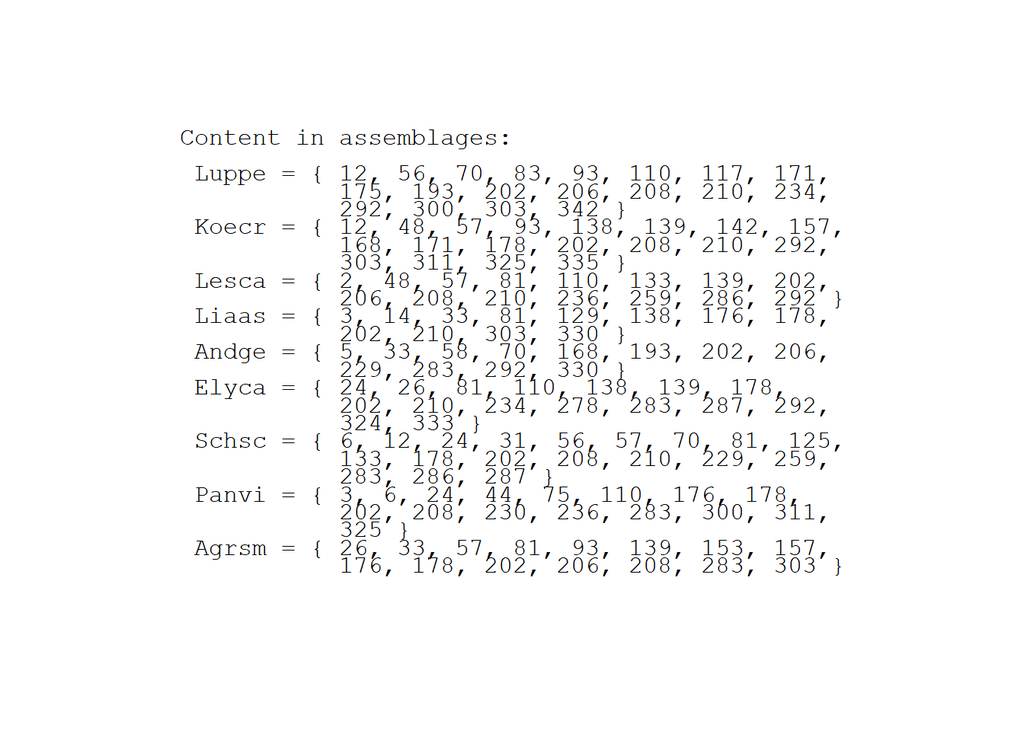

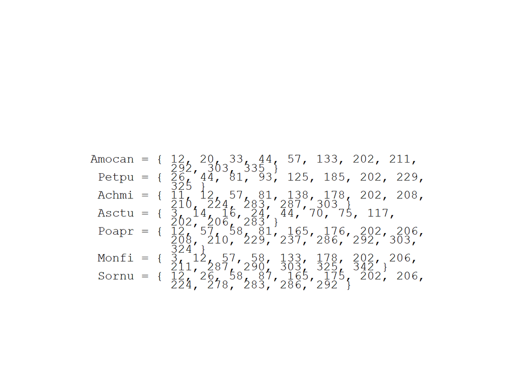

Opt.comp=list(‘tree’, ‘leg’) plots set of performances that contain a given component, sorted as the hierarchical tree of components

```r
fclust_plot(res, main = "BioDiv2", opt.comp = list("tree", "leg", "aov", pvalue = 0.01))
```